# Ie360 Spring22 HW1

Ersu DEDEAĞAOĞLU / 2018402081

4/13/2022

# Introduction

This assignment aims to manipulate the data in a proper way, and to visualize the variables in order to understand their time-related behavior as well as the relation between each other. In this sense, “USD/TL Exchange Rates”, “Transportation Price Index”, “Airline Spending” from the TCMB site, and “Airline ticket searches” from Google Trends, covering the dates between 2015-01 and 2018-12 are chosen. This choice was made with the assumption that these four data are somehow related, and at the end of the study, the correlation values were tested to test the accuracy of this assumption. In order to examine patterns within the data, each data is observed with the use of different plot types like boxplots, lines and barplots, while correlation plot and pairs plot is used to identify relation between different variables.

# Data Manipulation and Visualization of the Measures

## Libraries

```r
library(readxl)
library(skimr)
library(janitor)
library(readr)
library(tidyverse)
library(fBasics)
library(dplyr)
library(data.table)
library(writexl)
library(scales)
library(plyr)
library(zoo)
library(lubridate)
library(ggplot2)
library(forecast)
library(corrplot)
library(ggcorrplot)
```

## Import the data

```r
setwd("C:/Users/Erkut/Desktop/ie 360")

### Load 3 Series From TC Central Bank Site, and a quick check
mb <- read_excel("EVDS-.xlsx")
mb <- mb[c(1:48),]
summary(mb)
```

```
##     Tarih           TP KKHARTUT KT10   TP DK USD A YTL      TP FG J07
##  Length:48          Length:48          Length:48          Min.   :229.8
##  Class :character   Class :character   Class :character   1st Qu.:248.3
##  Mode  :character   Mode  :character   Mode  :character   Median :280.7
##                                                           Mean   :292.4
##                                                           3rd Qu.:327.7
##                                                           Max.   :419.2
```

```r
str(mb)
```

```
## tibble [48 x 4] (S3: tbl_df/tbl/data.frame)
##  $ Tarih           : chr [1:48] "2015-01" "2015-02" "2015-03" "2015-04" ...
##  $ TP KKHARTUT KT10: chr [1:48] "779067" "655432" "741419" "769947" ...
##  $ TP DK USD A YTL : chr [1:48] "2.3283428571429" "2.455225" "2.5838409090909" "2.6481428571429" ...
##  $ TP FG J07       : num [1:48] 230 234 236 237 241 ...
```

```r
### Correct the data types
mb$`TP KKHARTUT KT10` <- as.numeric(mb$`TP KKHARTUT KT10`)
mb$`TP DK USD A YTL` <- as.numeric(mb$`TP DK USD A YTL`)
mb$Tarih=ym(mb$Tarih)
str(mb)
```

```
## tibble [48 x 4] (S3: tbl_df/tbl/data.frame)
##  $ Tarih           : Date[1:48], format: "2015-01-01" "2015-02-01" ...
##  $ TP KKHARTUT KT10: num [1:48] 779067 655432 741419 769947 1044788 ...
##  $ TP DK USD A YTL : num [1:48] 2.33 2.46 2.58 2.65 2.65 ...
##  $ TP FG J07       : num [1:48] 230 234 236 237 241 ...
```

```r
### smash the table into vectors
date <- mb$Tarih
air_spending <- mb$`TP KKHARTUT KT10`
usdrate <- mb$`TP DK USD A YTL`
trPI <- mb$`TP FG J07`

### Search for "Uçak Bileti" From Google Trends
ticket <- read.csv("ticketsearch_.csv")
ticket <- ticket[2:49,]
ticket <- as.numeric(ticket)

### Collect date and other variables in a single data frame.
df <- data.frame("Date" = date, "Year" = format(date, "%Y"),
                 "Month" = format(date, "%m"), "Usd_rate" = usdrate,
                 "airline_spending" = air_spending,
                 "Transportation_PI" = trPI, "Ticket_search" = ticket)

### Split each variable to observe their patterns
spending_df <- df[,c(1,2,3,5)]
exchange_df <- df[,c(1,2,3,4)]
tPI_df <- df[,c(1,2,3,6)]
tsearch_df <- df[,c(1,2,3,7)]
```

## Histogram, Line and Boxplots

### Total Airline Spending

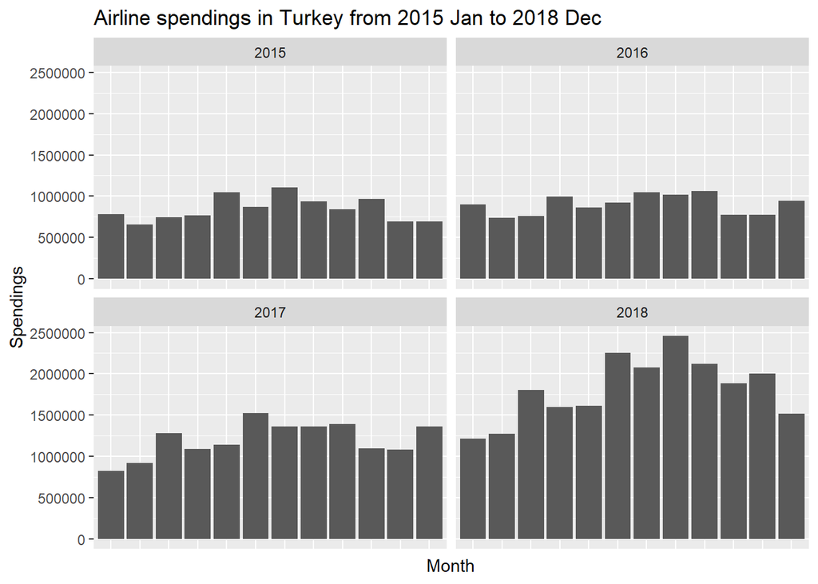

```r
ggplot(spending_df,aes(x=Month,y=airline_spending))+ geom_bar(stat='identity')+
  facet_wrap(~Year)+
  theme(legend.position = "none",
        axis.ticks.x = element_blank(),
        axis.text.x = element_blank())+
  ylab("Spendings")+ ggtitle("Airline spendings in Turkey from 2015 Jan to 2018 Dec")
```

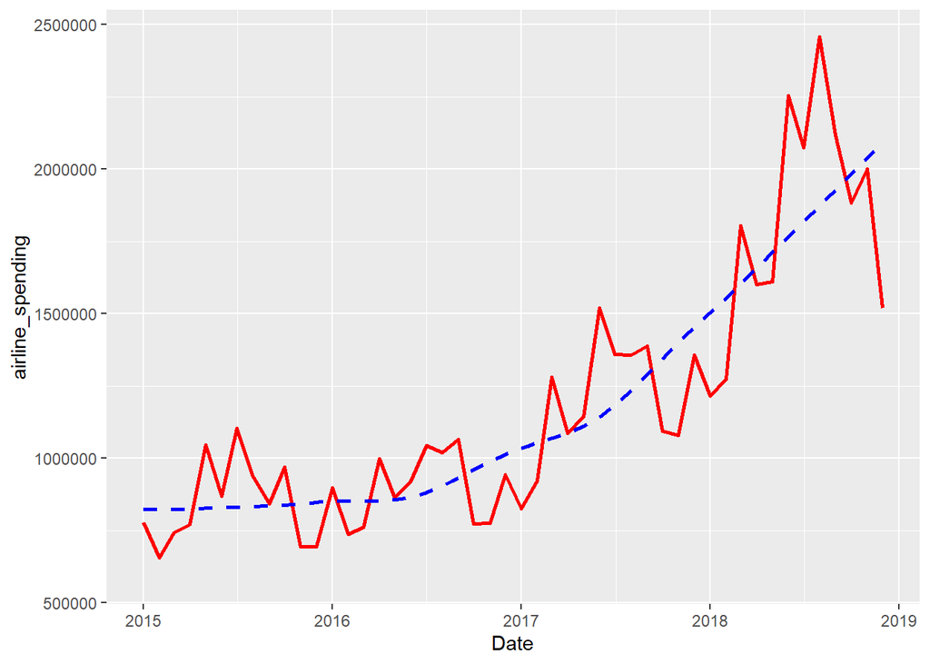

```r
ggplot(spending_df,aes(x=Date))+
  geom_line(size=1,color="red",aes(y=airline_spending))+
  geom_smooth(color='blue',linetype='dashed',size=1,fill=NA,aes(y=airline_spending))
```

```r
  ggtitle("Airline spendings in Turkey",
          subtitle="Between 2015-01 and 2018-12")
```

```
## $title
## [1] "Airline spendings in Turkey"
##
## $subtitle
## [1] "Between 2015-01 and 2018-12"
##
## attr(,"class")
## [1] "labels"
```

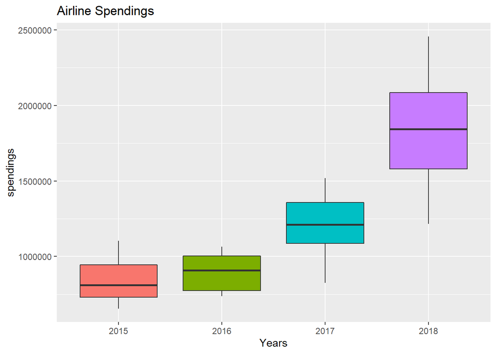

```r
 ggplot(spending_df,aes(x=factor(Year),y=airline_spending))+ geom_boxplot(aes(fill=factor(Year)))+
  xlab("Years") + ylab("spendings")+ ggtitle("Airline Spendings")+
  theme(legend.position = "none")
```

It is possible to mention a general increasing trend on the airline spending data. This increase can be resulting from either no of tickets sold is increased or the price per unit is increased, but probably from both. It is useful to look at price index data for this purpose. Also, the acceleration rate in the trend seems starting to increase in 2017, and it gains a real speed in 2018. Moreover, there seems an increase in the summer months where the weather gets better and people goes to holiday trips. This is an expected seasonal pattern.

When it comes to boxplot, In 2018, the Interquartile range is higher and whiskers are longer, indicating that the variance of the observations is higher in 2018. Other 3 years can be interpreted as more stable.

### USD/TL Rate

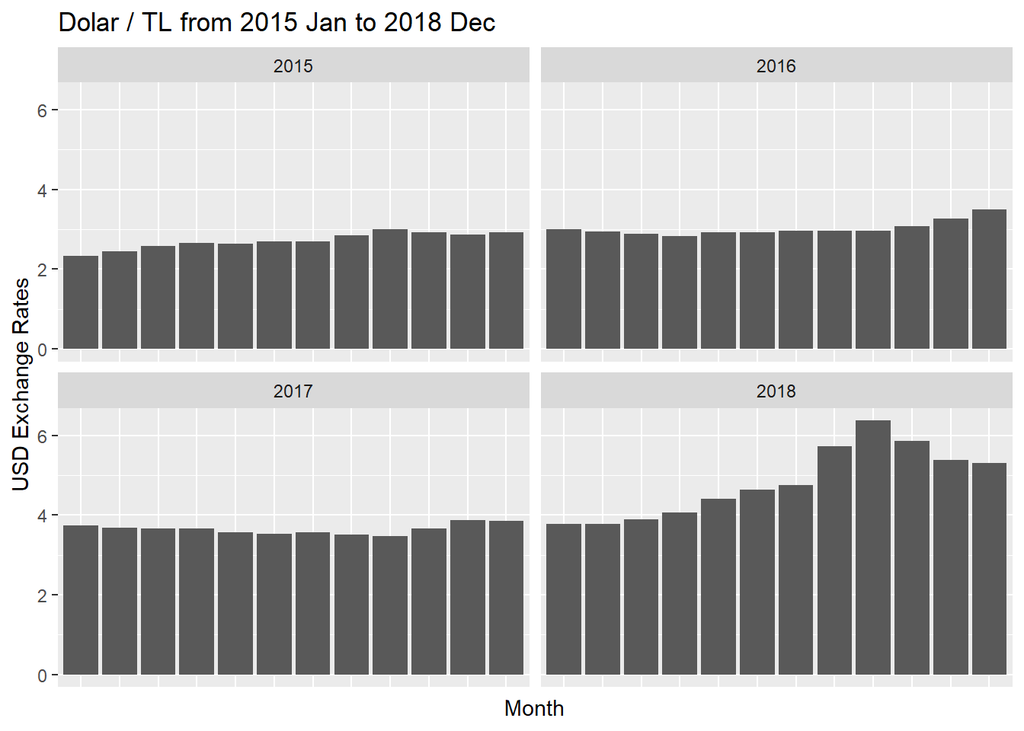

```r
ggplot(exchange_df,aes(x=Month,y=Usd_rate))+ geom_bar(stat='identity')+
  facet_wrap(~Year)+
  theme(legend.position = "none",
        axis.ticks.x = element_blank(),
        axis.text.x = element_blank())+
  ylab("USD Exchange Rates")+ ggtitle("Dolar / TL from 2015 Jan to 2018 Dec")
```

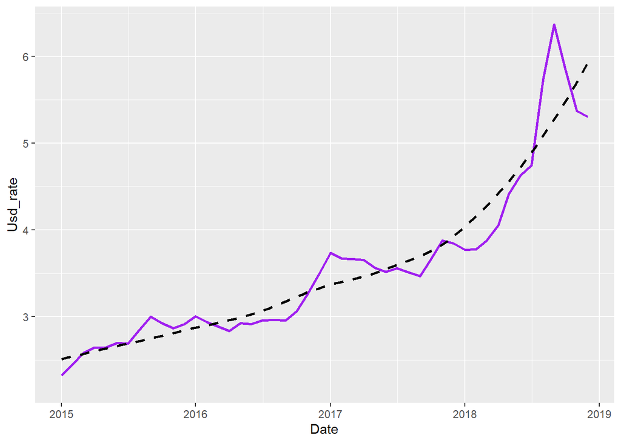

```r
ggplot(exchange_df,aes(x=Date))+
  geom_line(size=1,color="purple",aes(y=Usd_rate))+
  geom_smooth(color='black',linetype='dashed',size=1,fill=NA,aes(y=Usd_rate))
```

```r
  ggtitle("Exchange Rates(USD/TL)",
          subtitle="Between 2015-01 and 2018-12")
```

```
## $title
## [1] "Exchange Rates(USD/TL)"
##
## $subtitle
## [1] "Between 2015-01 and 2018-12"
##
## attr(,"class")
## [1] "labels"
```

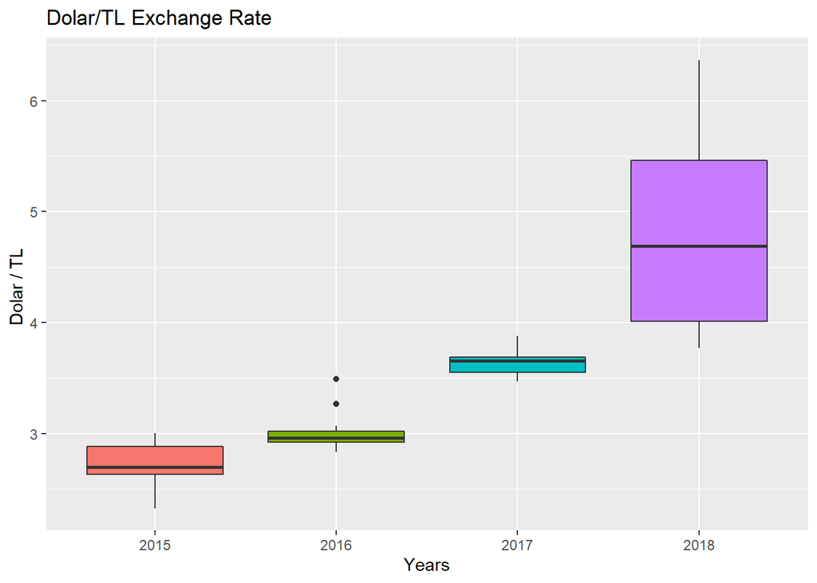

```r
  ggplot(exchange_df,aes(x=factor(Year),y=Usd_rate))+ geom_boxplot(aes(fill=factor(Year)))+
  xlab("Years") + ylab("Dolar / TL ")+ ggtitle("Dolar/TL Exchange Rate")+
  theme(legend.position = "none")
```

It is possible to talk about a general increase in the dollar/tl exchange rate. Excluding the exceptional rapid increase in 2018, a stable trend can be mentioned. Since the biggest reasons for the periodic rapid fluctuations in the exchange rate are the political environment, it may be necessary to make arrangements in this regard in order not to disturb the relationship with other variables while designing a forecasting model.

The boxplot gets wider also here. However, here, besides the fact that the dollar rate actually moves more dispersedly in 2018, it makes more sense to consider the proportional change. For this reason, the boxplot can lead to some misleading interpretations, but it is worthwhile to browse carefully.

### Transportation Price Index

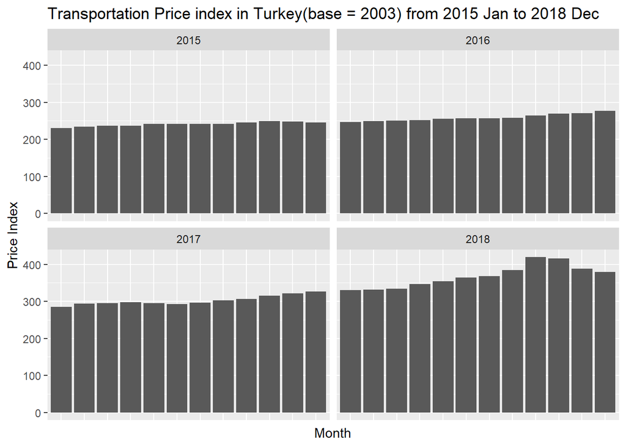

```r
ggplot(tPI_df,aes(x=Month,y=Transportation_PI))+ geom_bar(stat='identity')+
  facet_wrap(~Year)+
  theme(legend.position = "none",
        axis.ticks.x = element_blank(),
        axis.text.x = element_blank())+
  ylab("Price Index")+ ggtitle("Transportation Price index in Turkey(base = 2003) from 2015 Jan to 2018 Dec")
```

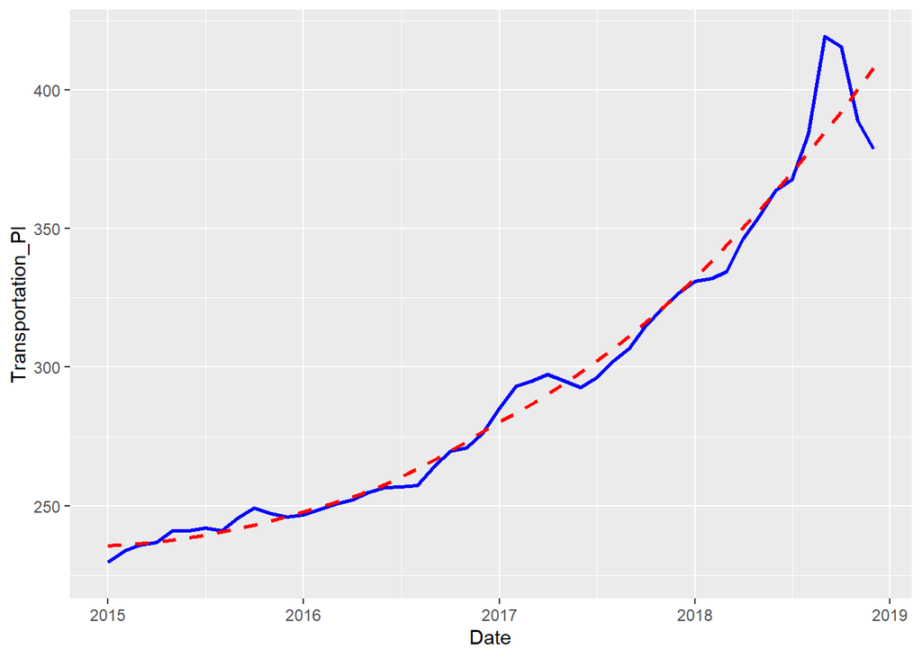

```r
ggplot(tPI_df,aes(x=Date))+
  geom_line(size=1,color="blue",aes(y=Transportation_PI))+
  geom_smooth(color='red',linetype='dashed',size=1,fill=NA,aes(y=Transportation_PI))
```

```r
  ggtitle("Transportatin PI (base = 2003) in Turkey",
          subtitle="Between 2015-01 and 2018-12")
```

```
## $title
## [1] "Transportatin PI (base = 2003) in Turkey"
##
## $subtitle
## [1] "Between 2015-01 and 2018-12"
##
## attr(,"class")
## [1] "labels"
```

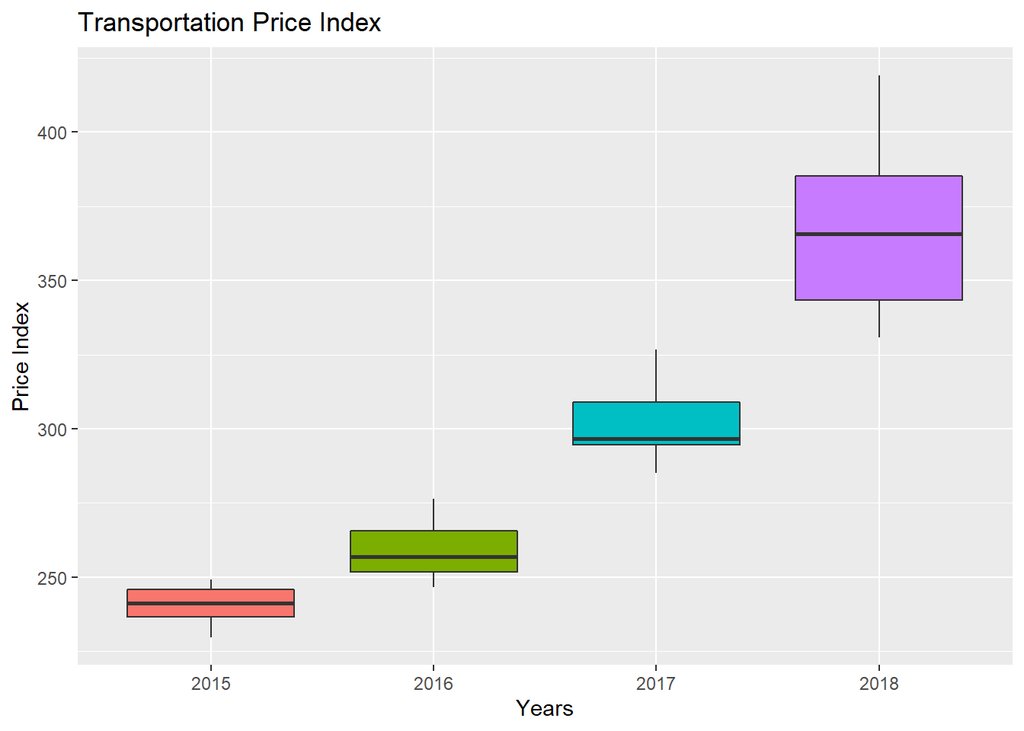

```r
  ggplot(tPI_df,aes(x=factor(Year),y=Transportation_PI))+ geom_boxplot(aes(fill=factor(Year)))+
  xlab("Years") + ylab("Price Index")+ ggtitle("Transportation Price Index")+
  theme(legend.position = "none")
```

It is already possible to see that the transportation price index is highly correlated with the dollar rate. Economic reasons such as high import rate and current account deficit may have created this correlation. This was an expected behavior. Boxplot interpretation is also very similar to the dollar rate.

### “Uçak Bileti” Search

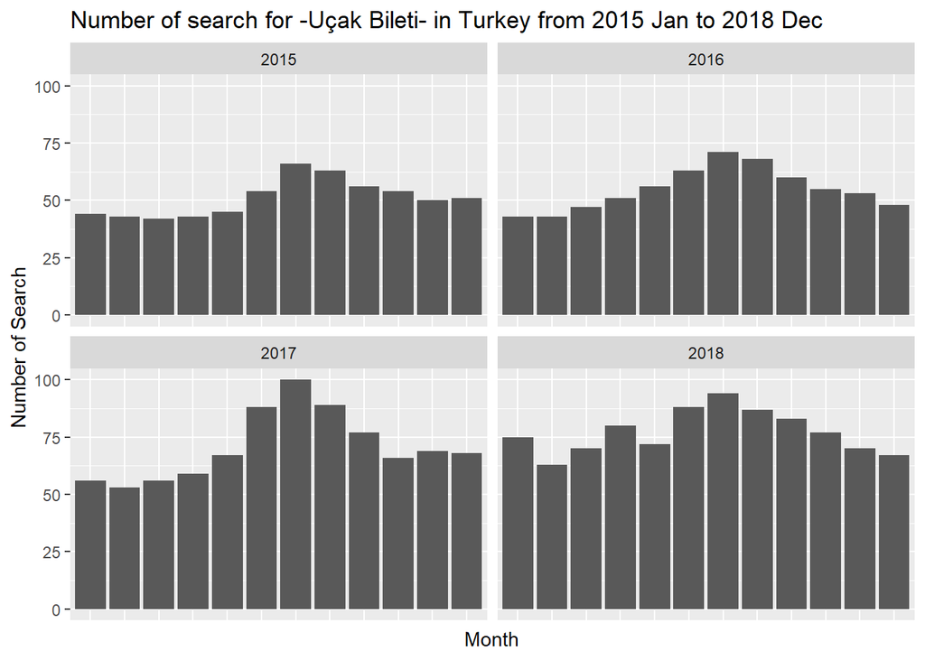

```r
ggplot(tsearch_df,aes(x=Month,y=Ticket_search))+ geom_bar(stat='identity')+
  facet_wrap(~Year)+
  theme(legend.position = "none",
        axis.ticks.x = element_blank(),
        axis.text.x = element_blank())+
  ylab("Number of Search")+ ggtitle("Number of search for -Uçak Bileti- in Turkey from 2015 Jan to 2018 Dec")
```

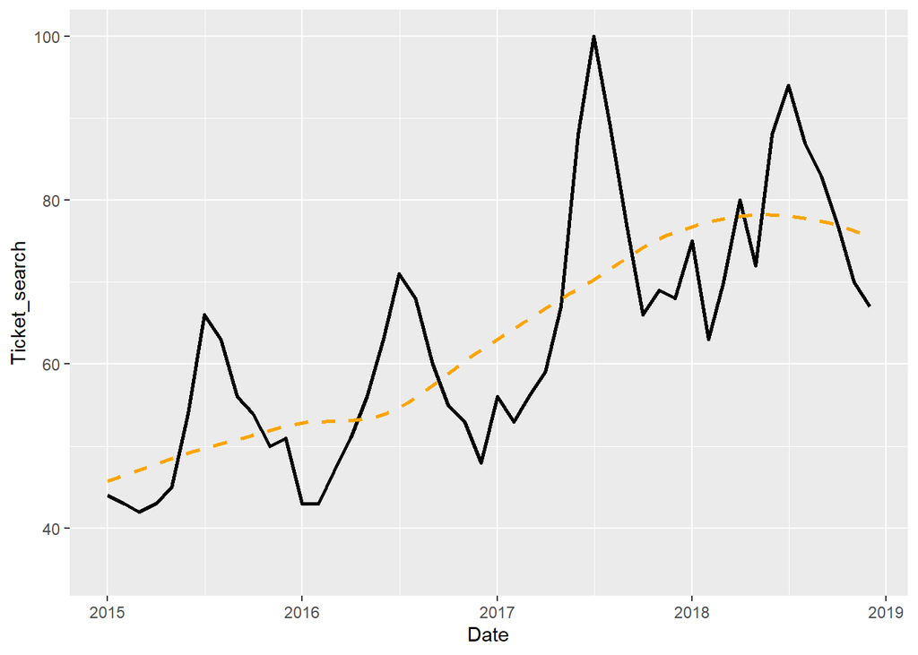

```r
ggplot(tsearch_df,aes(x=Date))+
  geom_line(size=1,color="black",aes(y=Ticket_search))+
  geom_smooth(color='orange',linetype='dashed',size=1,fill=NA,aes(y=Ticket_search))
```

```r
  ggtitle("Airline spendings in Turkey",
          subtitle="Between 2015-01 and 2018-12")
```

```
## $title
## [1] "Airline spendings in Turkey"
##
## $subtitle
## [1] "Between 2015-01 and 2018-12"
##
## attr(,"class")
## [1] "labels"
```

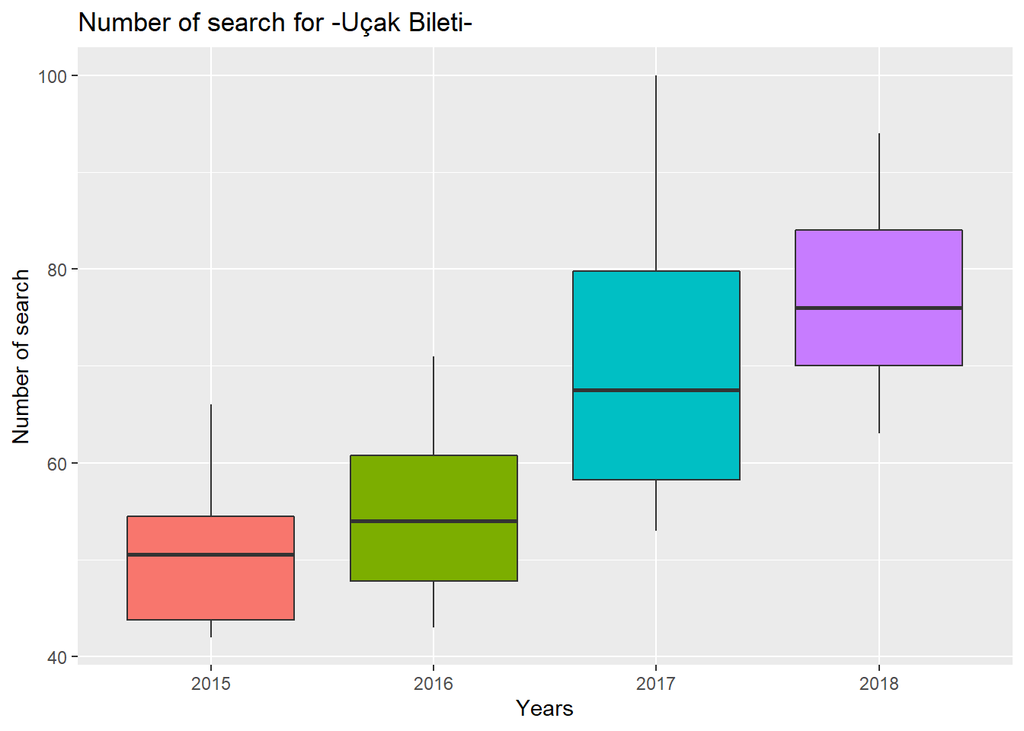

```r
  ggplot(tsearch_df,aes(x=factor(Year),y=Ticket_search))+ geom_boxplot(aes(fill=factor(Year)))+
  xlab("Years") + ylab("Number of search")+ ggtitle("Number of search for -Uçak Bileti-")+
  theme(legend.position = "none")
```

There are clearly visible trend and seasonality components in “Uçak Bileti” searches. It is possible to talk about a trend that tends to increase from year to year, and a seasonal pattern that accelerates towards the summer months and then slows down. At first glance, it can be interpreted that it has some movements independent of other variables, so its correlation may not be excessively high.

## Correlation Check

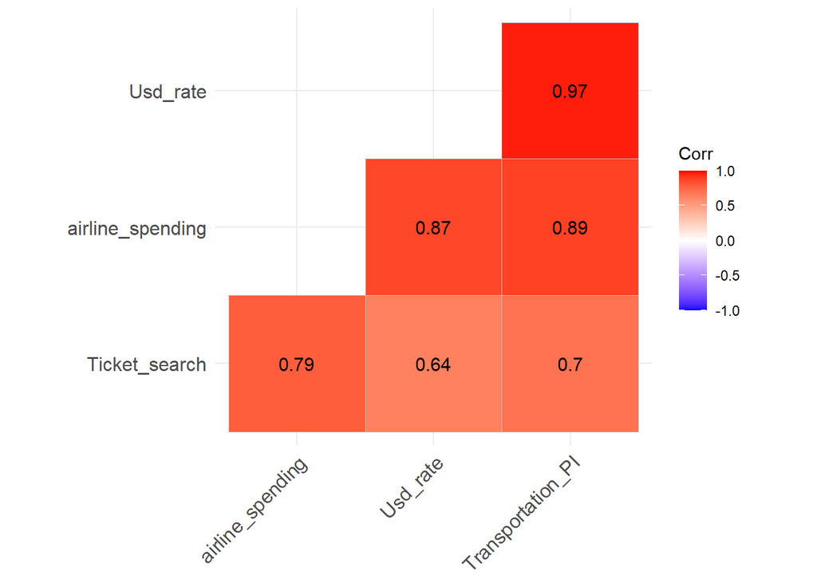

```r
corr = cor(df[,c(4,5,6,7)])
ggcorrplot(corr,
           hc.order = TRUE,
           type='lower',
           lab=TRUE)
```

As expected, there is an excessive correlation between USD/TL rate and Transportation Price Index, arising from some macro economical type of discussions. This increase in the exchange rate leads to an increase in total spending, as it is directly reflected in ticket prices. An interesting point here is that there is a very high correlation between the inflation rate in transportation and the total expenditure on airlines. The reason for this up to a point is the direct reflection of the increase in ticket prices on total expenditure, as mentioned above. However, the reason that carries up to 0.89 correlation may be that this inflation mostly comes from road and rail transportation and people have come to the “Let’s check the plane tickets too” approach because the prices are now close to each other. Finally, it is expected the more people search for airline tickets, the more people buy it in total. So, the correlation of 0.79 between ticket search and airline spending is reasonable.

## Pairs Plot

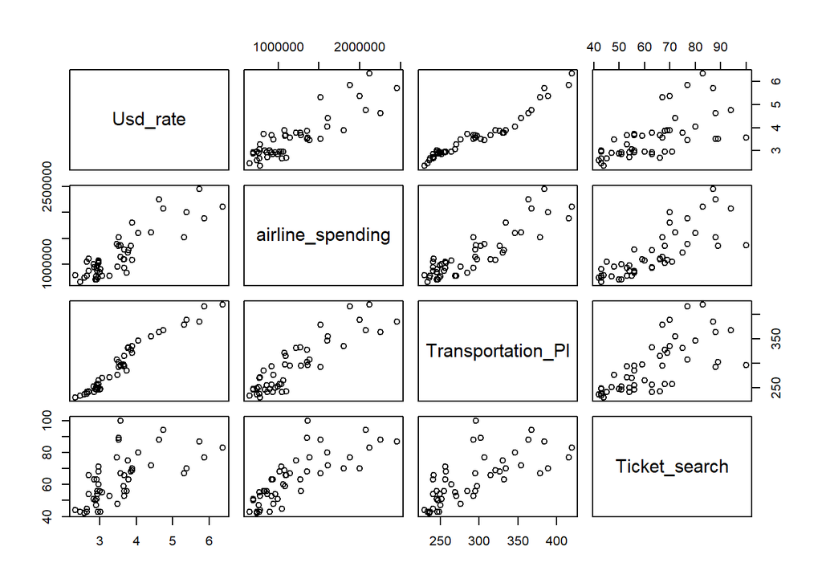

```r
pairs(df[,c(4,5,6,7)])
```

As we can see from the graphs, when we examine the variables in pairs, we can see that there is indeed a correlation between them. Of course, the extent of this correlation varies. For example, the 0.97 correlation between USD Rate and Transportation PI comes across as an almost straight line. It is possible to detect a more diffuse relationship (lower correlation) between “Uçak Bileti” search and Transportation PI.

# Conclusion